# Attrition Prediction

Christian Orji

2023-04-01

```r
library(tidyverse)
```

```r
library(ggplot2)
library(lattice)
library(caret)
library(glmnet)
library(naivebayes)
library(e1071)
library(scales)
library(caret)
library(dplyr)
```

# load the data and get the dimensions

```r
talent_data <- read.table(file = "CaseStudy2-data.txt", sep=",", header = T, na.strings = c("NA", "", " "), stringsAsFactors = T)

No_Attrition <- read.table(file = "No_Attrition.txt", sep=",", header = T, na.strings = c("NA", "", " "), stringsAsFactors = T)

No_MonthlyIncome <- read.csv(file = "No_MonthlyIncome.csv", sep=",", header = T, na.strings = c("NA", "", " "), stringsAsFactors = T)

dim(talent_data)
```

```
## [1] 870  36
```

Data preparation: We’ve already loaded the dataset into R. Now, let’s inspect the data and clean it.

```r
# Check for missing values
sum(is.na(talent_data))
```

```
## [1] 0
```

```r
# Check for duplicates
sum(duplicated(talent_data))
```

```
## [1] 0
```

```r
# Inspect data types
str(talent_data)
```

```
## 'data.frame':    870 obs. of  36 variables:
##  $ ID                      : int  1 2 3 4 5 6 7 8 9 10 ...
##  $ Age                     : int  32 40 35 32 24 27 41 37 34 34 ...
##  $ Attrition               : Factor w/ 2 levels "No","Yes": 1 1 1 1 1 1 1 1 1 1 ...
##  $ BusinessTravel          : Factor w/ 3 levels "Non-Travel","Travel_Frequently",..: 3 3 2 3 2 2 3 3 3 2 ...
##  $ DailyRate               : int  117 1308 200 801 567 294 1283 309 1333 653 ...
##  $ Department              : Factor w/ 3 levels "Human Resources",..: 3 2 2 3 2 2 2 3 3 2 ...
##  $ DistanceFromHome        : int  13 14 18 1 2 10 5 10 10 10 ...
##  $ Education               : int  4 3 2 4 1 2 5 4 4 4 ...
##  $ EducationField          : Factor w/ 6 levels "Human Resources",..: 2 4 2 3 6 2 4 2 2 6 ...
##  $ EmployeeCount           : int  1 1 1 1 1 1 1 1 1 1 ...
##  $ EmployeeNumber          : int  859 1128 1412 2016 1646 733 1448 1105 1055 1597 ...
##  $ EnvironmentSatisfaction : int  2 3 3 3 1 4 2 4 3 4 ...
##  $ Gender                  : Factor w/ 2 levels "Female","Male": 2 2 2 1 1 2 2 1 1 2 ...
##  $ HourlyRate              : int  73 44 60 48 32 32 90 88 87 92 ...
```

[output cut: 22 more lines]

# Exploratory data analysis (EDA): Perform summary statistics and visualizations to understand the data distribution and relationships.

```r
# Summary statistics
summary(talent_data)
```

```
##        ID             Age        Attrition           BusinessTravel
##  Min.   :  1.0   Min.   :18.00   No :730   Non-Travel       : 94
##  1st Qu.:218.2   1st Qu.:30.00   Yes:140   Travel_Frequently:158
##  Median :435.5   Median :35.00             Travel_Rarely    :618
##  Mean   :435.5   Mean   :36.83
##  3rd Qu.:652.8   3rd Qu.:43.00
##  Max.   :870.0   Max.   :60.00
##
##    DailyRate                       Department  DistanceFromHome   Education
##  Min.   : 103.0   Human Resources       : 35   Min.   : 1.000   Min.   :1.000
##  1st Qu.: 472.5   Research & Development:562   1st Qu.: 2.000   1st Qu.:2.000
##  Median : 817.5   Sales                 :273   Median : 7.000   Median :3.000
##  Mean   : 815.2                                Mean   : 9.339   Mean   :2.901
##  3rd Qu.:1165.8                                3rd Qu.:14.000   3rd Qu.:4.000
##  Max.   :1499.0                                Max.   :29.000   Max.   :5.000
##
##           EducationField EmployeeCount EmployeeNumber   EnvironmentSatisfaction
##  Human Resources : 15    Min.   :1     Min.   :   1.0   Min.   :1.000
##  Life Sciences   :358    1st Qu.:1     1st Qu.: 477.2   1st Qu.:2.000
##  Marketing       :100    Median :1     Median :1039.0   Median :3.000
##  Medical         :270    Mean   :1     Mean   :1029.8   Mean   :2.701
##  Other           : 52    3rd Qu.:1     3rd Qu.:1561.5   3rd Qu.:4.000
##  Technical Degree: 75    Max.   :1     Max.   :2064.0   Max.   :4.000
##
##     Gender      HourlyRate     JobInvolvement     JobLevel
##  Female:354   Min.   : 30.00   Min.   :1.000   Min.   :1.000
##  Male  :516   1st Qu.: 48.00   1st Qu.:2.000   1st Qu.:1.000
##               Median : 66.00   Median :3.000   Median :2.000
##               Mean   : 65.61   Mean   :2.723   Mean   :2.039
##               3rd Qu.: 83.00   3rd Qu.:3.000   3rd Qu.:3.000
##               Max.   :100.00   Max.   :4.000   Max.   :5.000
##
##                       JobRole    JobSatisfaction  MaritalStatus MonthlyIncome
##  Sales Executive          :200   Min.   :1.000   Divorced:191   Min.   : 1081
##  Research Scientist       :172   1st Qu.:2.000   Married :410   1st Qu.: 2840
##  Laboratory Technician    :153   Median :3.000   Single  :269   Median : 4946
##  Manufacturing Director   : 87   Mean   :2.709                  Mean   : 6390
##  Healthcare Representative: 76   3rd Qu.:4.000                  3rd Qu.: 8182
##  Sales Representative     : 53   Max.   :4.000                  Max.   :19999
##  (Other)                  :129
```

[output cut: 17 more lines]

```
##  Min.   : 0.00     Min.   :0.000         Min.   :1.000   Min.   : 0.000
##  1st Qu.: 6.00     1st Qu.:2.000         1st Qu.:2.000   1st Qu.: 3.000
##  Median :10.00     Median :3.000         Median :3.000   Median : 5.000
##  Mean   :11.05     Mean   :2.832         Mean   :2.782   Mean   : 6.962
##  3rd Qu.:15.00     3rd Qu.:3.000         3rd Qu.:3.000   3rd Qu.:10.000
##  Max.   :40.00     Max.   :6.000         Max.   :4.000   Max.   :40.000
##
##  YearsInCurrentRole YearsSinceLastPromotion YearsWithCurrManager
##  Min.   : 0.000     Min.   : 0.000          Min.   : 0.00
##  1st Qu.: 2.000     1st Qu.: 0.000          1st Qu.: 2.00
##  Median : 3.000     Median : 1.000          Median : 3.00
##  Mean   : 4.205     Mean   : 2.169          Mean   : 4.14
##  3rd Qu.: 7.000     3rd Qu.: 3.000          3rd Qu.: 7.00
##  Max.   :18.000     Max.   :15.000          Max.   :17.00
##
```

Based on the dataset provided, there are 870 observations, with 34 features and the target variable ‘Attrition’. The dataset contains various information about employees such as demographic details (Age, Gender, MaritalStatus), job-related details (BusinessTravel, DailyRate, Department, DistanceFromHome, JobRole, etc.), and work experience (TotalWorkingYears, YearsAtCompany, YearsInCurrentRole, YearsWithCurrManager).

# Feature engineering: Based on the EDA results, we do not need to create or transform features.

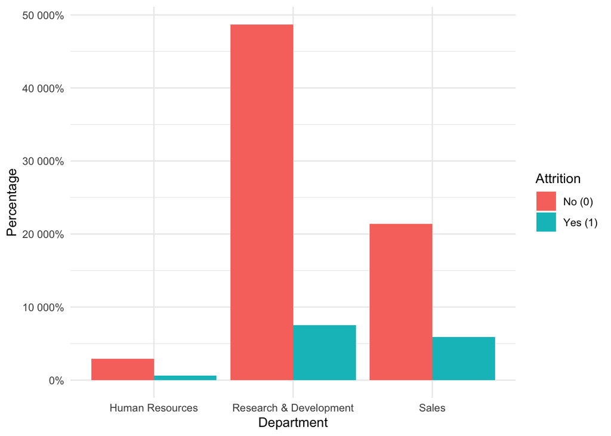

```r
# Load required libraries
library(ggplot2)
library(scales)

# Attrition by department
department_plot <- ggplot(talent_data, aes(x = Department, fill = Attrition)) +
  geom_bar(position = "dodge") +
  theme_minimal() +
  ylab("Percentage") +
  scale_fill_discrete(labels = c("No (0)", "Yes (1)")) +
  scale_y_continuous(labels = percent)

print(department_plot)
```

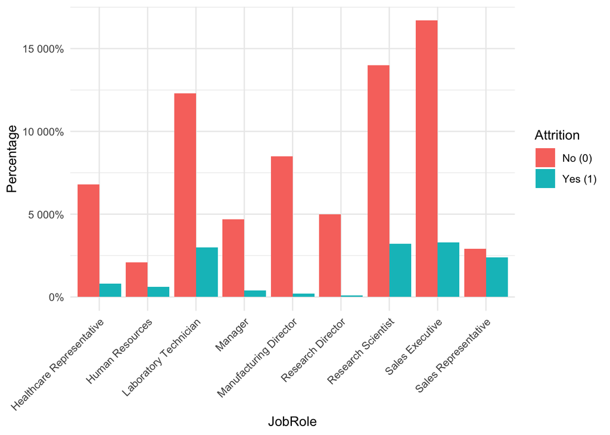

```r
# Attrition by job role
jobrole_plot <- ggplot(talent_data, aes(x = JobRole, fill = Attrition)) +
  geom_bar(position = "dodge") +
  theme_minimal() +
  theme(axis.text.x = element_text(angle = 45, hjust = 1)) +
  ylab("Percentage") +
  scale_fill_discrete(labels = c("No (0)", "Yes (1)")) +
  scale_y_continuous(labels = percent)

print(jobrole_plot)
```

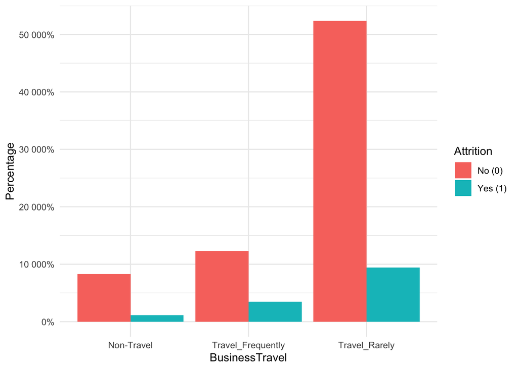

```r
# Attrition by business travel
business_travel_plot <- ggplot(talent_data, aes(x = BusinessTravel, fill = Attrition)) +
  geom_bar(position = "dodge") +
  theme_minimal() +
  ylab("Percentage") +
  scale_fill_discrete(labels = c("No (0)", "Yes (1)")) +
  scale_y_continuous(labels = percent)

print(business_travel_plot)
```

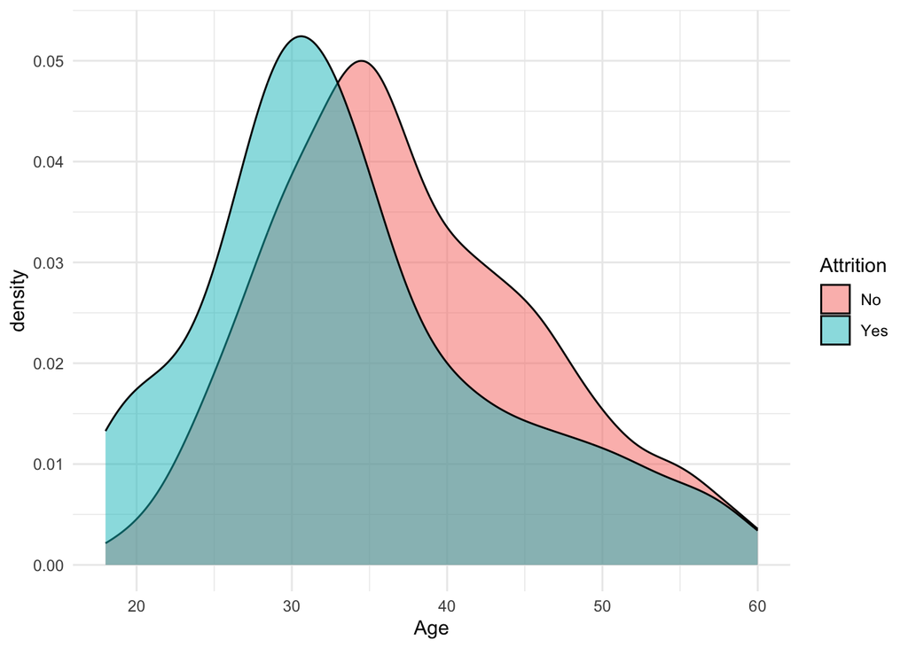

```r
# Age distribution by attrition
age_plot <- ggplot(talent_data, aes(x = Age, fill = Attrition)) +
  geom_density(alpha = 0.5) +
  theme_minimal()
print(age_plot)
```

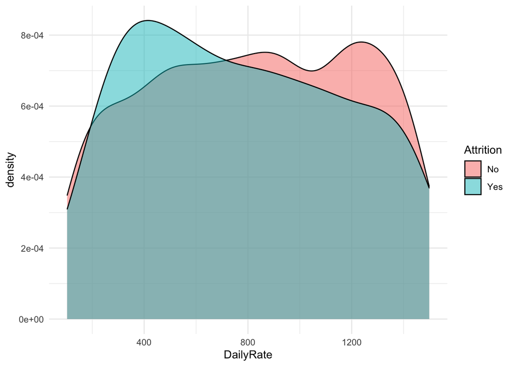

```r
# Attrition by DailyRate
dailyrate_plot <- ggplot(talent_data, aes(x = DailyRate, fill = Attrition)) +
  geom_density(alpha = 0.5) +
  theme_minimal()
print(dailyrate_plot)
```

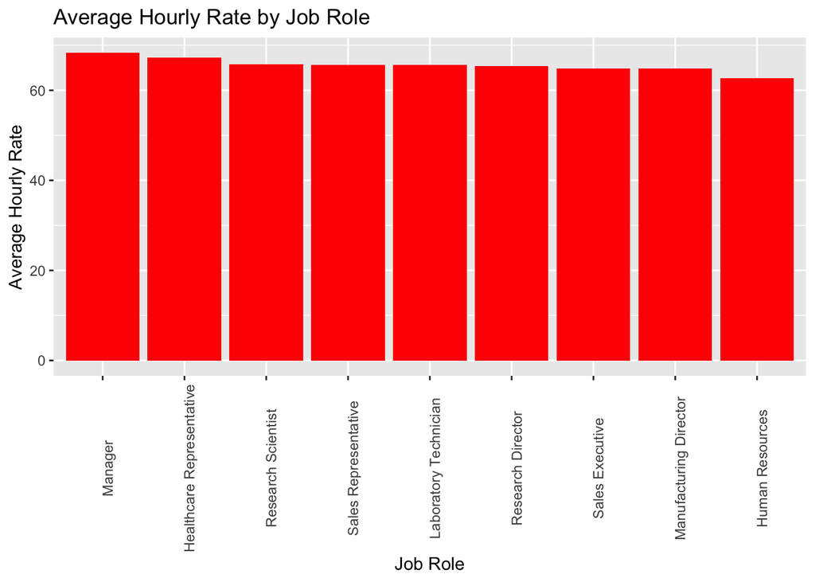

```r
# Visually showing what job role has the highest average hourly rate.
talent_data %>% group_by(JobRole) %>% summarise(meanHourlyRate = mean(HourlyRate)) %>% ggplot(aes(x = reorder(JobRole, -meanHourlyRate), y = meanHourlyRate)) + geom_col(fill = "red") + ggtitle("Average Hourly Rate by Job Role") + ylab("Average Hourly Rate") + xlab("Job Role") + theme(axis.text.x = element_text(angle = 90))
```

# Managers have the highest hourly rate.

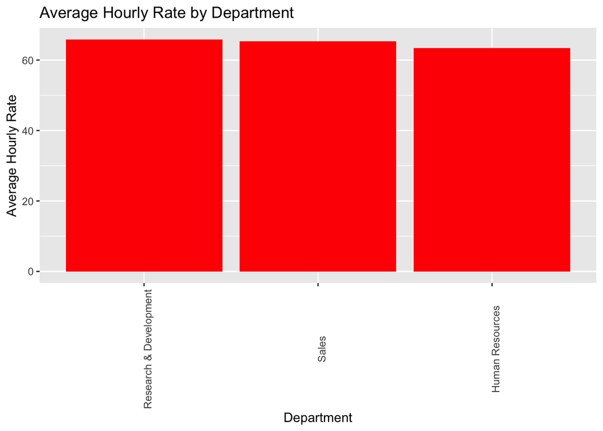

```r
# Visually showing what department has the highest average hourly rate.
talent_data %>% group_by(Department) %>% summarise(meanHourlyRate = mean(HourlyRate)) %>% ggplot(aes(x = reorder(Department, -meanHourlyRate), y = meanHourlyRate)) + geom_col(fill = "red") + ggtitle("Average Hourly Rate by Department") + ylab("Average Hourly Rate") + xlab("Department") + theme(axis.text.x = element_text(angle = 90))
```

# Research and Development has the highest hourly rate.

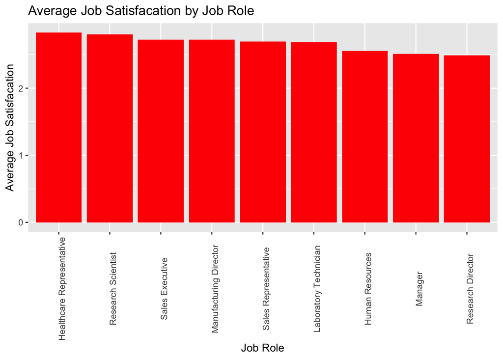

```r
# Visually showing what job role has the highest average job satisfaction.
talent_data %>% group_by(JobRole) %>% summarise(meanJobSat = mean(JobSatisfaction)) %>% ggplot(aes(x = reorder(JobRole, -meanJobSat), y = meanJobSat)) + geom_col(fill = "red") + ggtitle("Average Job Satisfacation by Job Role") + ylab("Average Job Satisfacation") + xlab("Job Role") + theme(axis.text.x = element_text(angle = 90))
```

# Health Care Representatives have the highest average job satisfaction.

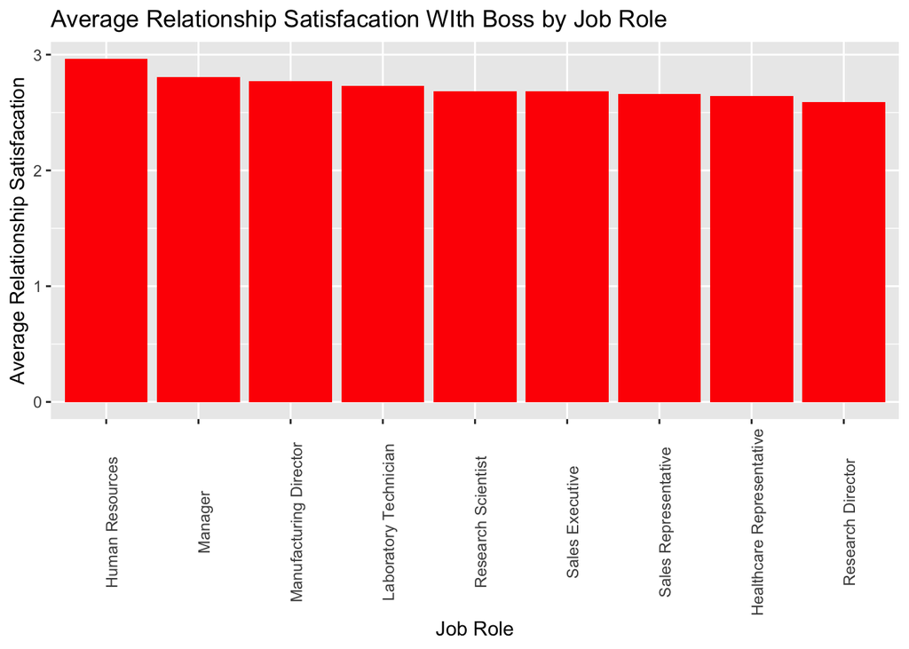

```r
# Visually showing what job role has the highest average relationship satisfaction with boss.
talent_data %>% group_by(JobRole) %>% summarise(meanRelSat = mean(RelationshipSatisfaction)) %>% ggplot(aes(x = reorder(JobRole, -meanRelSat), y = meanRelSat)) + geom_col(fill = "red") + ggtitle("Average Relationship Satisfacation WIth Boss by Job Role") + ylab("Average Relationship Satisfacation") + xlab("Job Role") + theme(axis.text.x = element_text(angle = 90))
```

# Human Resources has the highest average relationship satisfaction with their boss.

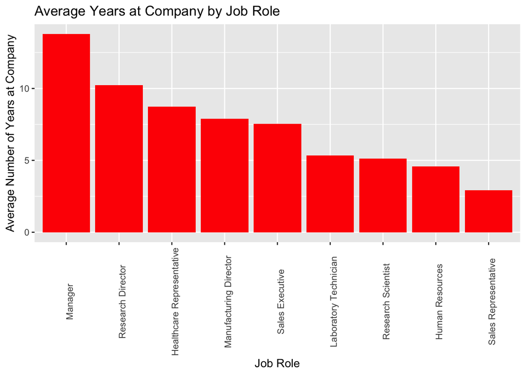

```r
# Visually showing what job role has the highest average number of years at the company.
talent_data %>% group_by(JobRole) %>% summarise(meanYrs = mean(YearsAtCompany)) %>% ggplot(aes(x = reorder(JobRole, -meanYrs), y = meanYrs)) + geom_col(fill = "red") + ggtitle("Average Years at Company by Job Role") + ylab("Average Number of Years at Company") + xlab("Job Role") + theme(axis.text.x = element_text(angle = 90))
```

# Managers have the highest average number of years at the company.

# Creating a separate data frame to create percentage of Attrition and Retention by Job Role variables

```r
Attrition <- talent_data %>%
  group_by(JobRole) %>%
  summarise(countTot = n())

Attrition2 <- talent_data %>%
  filter(Attrition == "Yes") %>%
  group_by(JobRole) %>%
  summarise(NumAttrition = n())

Attrition3 <- talent_data %>%
  filter(Attrition == "No") %>%
  group_by(JobRole) %>%
  summarise(NumRetention = n())

AttritionRetention <- merge(Attrition, Attrition2, by = "JobRole")
AttritionRetention2 <- merge(AttritionRetention, Attrition3, by = "JobRole")
AttritionRetention2$PercentAttrition <- (AttritionRetention2$NumAttrition/AttritionRetention2$countTot)*100
AttritionRetention2$PercentRetention <- (AttritionRetention2$NumRetention/AttritionRetention2$countTot)*100
AttritionRetention2
```

```
##                     JobRole countTot NumAttrition NumRetention PercentAttrition
## 1 Healthcare Representative       76            8           68        10.526316
## 2           Human Resources       27            6           21        22.222222
## 3     Laboratory Technician      153           30          123        19.607843
## 4                   Manager       51            4           47         7.843137
## 5    Manufacturing Director       87            2           85         2.298851
## 6         Research Director       51            1           50         1.960784
## 7        Research Scientist      172           32          140        18.604651
## 8           Sales Executive      200           33          167        16.500000
## 9      Sales Representative       53           24           29        45.283019
##   PercentRetention
## 1         89.47368
## 2         77.77778
## 3         80.39216
## 4         92.15686
## 5         97.70115
## 6         98.03922
## 7         81.39535
## 8         83.50000
## 9         54.71698
```

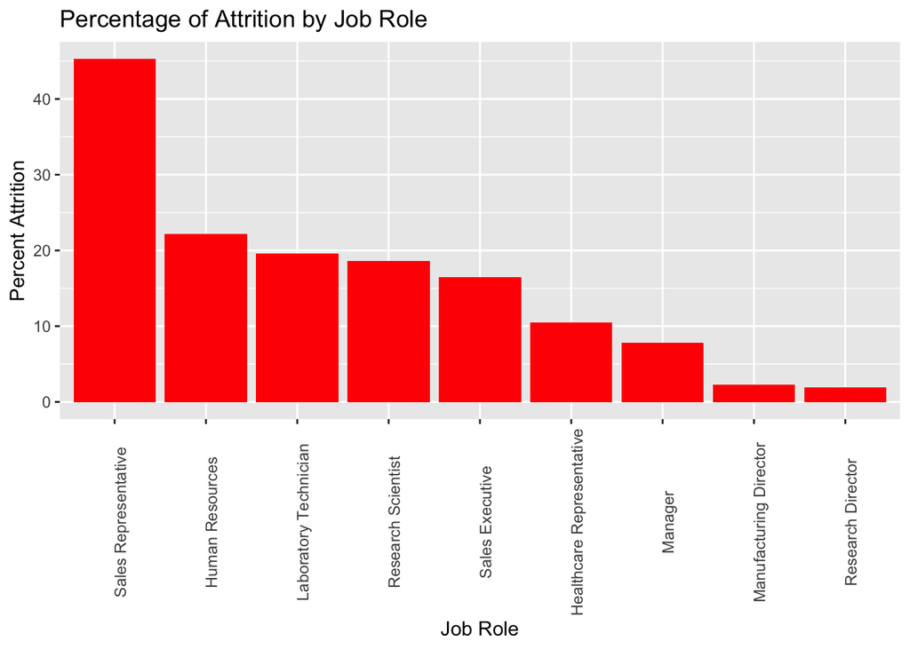

```r
# Visually showing the percent Attrition by job role in descending order.
AttritionRetention2 %>%
  ggplot(aes(x = reorder(JobRole, -PercentAttrition), y = PercentAttrition)) +
  geom_col(fill = "red") +
  ggtitle("Percentage of Attrition by Job Role") +
  ylab("Percent Attrition") +
  xlab("Job Role") +
  theme(axis.text.x = element_text(angle = 90))
```

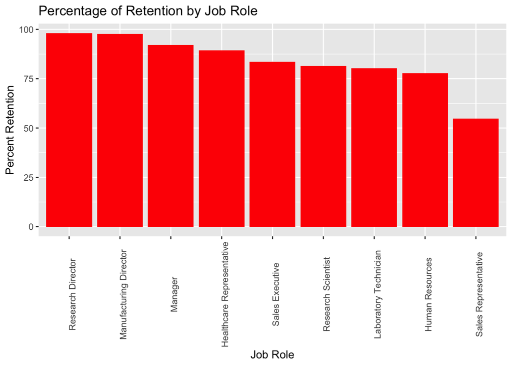

```r
# Visually showing the percent Retention by Job Role in descending order.
AttritionRetention2 %>%
  ggplot(aes(x = reorder(JobRole, -PercentRetention), y = PercentRetention)) +
  geom_col(fill = "red") +
  ggtitle("Percentage of Retention by Job Role") +
  ylab("Percent Retention") +
  xlab("Job Role") +
  theme(axis.text.x = element_text(angle = 90))
```

Sales Representative has the highest percentage of Attrition by job Role Research Director and Manufacturing Director has the highest percentage of Retention by job Role

# Model building: Split the dataset, create models, and evaluate their performance.

```r
# Encode Attrition as binary (0 = No, 1 = Yes)
talent_data$Attrition <- as.integer(talent_data$Attrition == "Yes")

# Split the dataset into training and testing sets
library(caret)
set.seed(42)
trainIndex <- createDataPartition(talent_data$Attrition, p = 0.8, list = FALSE, times = 1)
train_set <- talent_data[trainIndex,]
test_set <- talent_data[-trainIndex,]

# Create a logistic regression model
model <- glm(Attrition ~ Age + Department + MonthlyIncome + JobRole + JobSatisfaction, data = train_set, family = "binomial")

# Make predictions
predictions <- predict(model, test_set, type = "response")
predicted_classes <- ifelse(predictions > 0.5, 1, 0)

# Evaluate model performance
confusionMatrix(factor(predicted_classes), factor(test_set$Attrition))
```

```
## Confusion Matrix and Statistics
##
##           Reference
## Prediction   0   1
##          0 140  29
##          1   5   0
##
##                Accuracy : 0.8046
##                  95% CI : (0.7378, 0.8607)
##     No Information Rate : 0.8333
##     P-Value [Acc > NIR] : 0.8674
##
##                   Kappa : -0.0515
##
##  Mcnemar's Test P-Value : 7.998e-05
##
##             Sensitivity : 0.9655
##             Specificity : 0.0000
##          Pos Pred Value : 0.8284
##          Neg Pred Value : 0.0000
##              Prevalence : 0.8333
##          Detection Rate : 0.8046
##    Detection Prevalence : 0.9713
##       Balanced Accuracy : 0.4828
##
##        'Positive' Class : 0
##
```

# Adjusting the Sensitivity using the up sampling

```r
yes = which(talent_data$Attrition=="1")
no= which(talent_data$Attrition=="0")
length(yes)
```

```
## [1] 140
```

```r
length(no)
```

```
## [1] 730
```

```r
yes.upsampling= sample(yes,length(no), replace = TRUE)
length(yes.upsampling)
```

```
## [1] 730
```

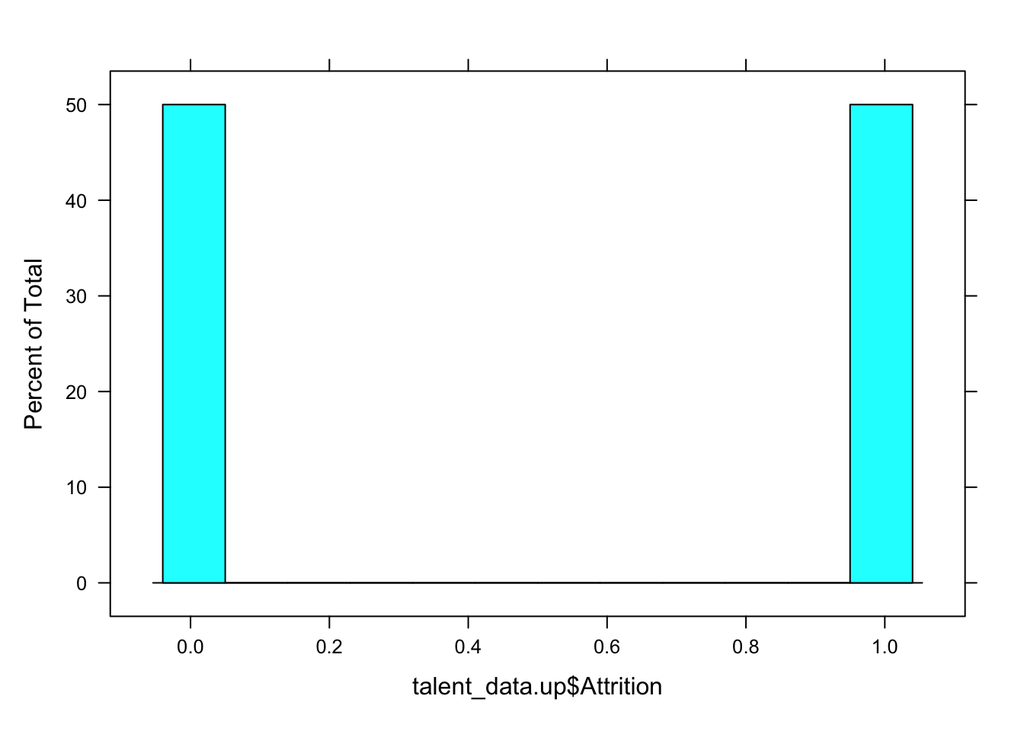

```r
talent_data.up = talent_data[c(yes.upsampling,no),]
histogram(talent_data.up$Attrition)
```

```r
# Encode Attrition as binary (0 = No, 1 = Yes)
#talent_data$Attrition <- as.integer(talent_data$Attrition == "Yes")

# Split the dataset into training and testing sets
library(caret)
set.seed(42)
trainIndex <- createDataPartition(talent_data.up$Attrition, p = 0.8, list = FALSE, times = 1)
train_set <- talent_data.up[trainIndex,]
test_set <- talent_data.up[-trainIndex,]

# Create a logistic regression model
model2 <- naiveBayes(Attrition ~ Age + Department + MonthlyIncome + JobRole + JobSatisfaction, data = train_set, laplace=1)

# Make predictions
predictions <- predict(model2, test_set, type = "class")
predicted_classes <- ifelse(predictions > 0.5, 1, 0)
# Evaluate model performance
confusionMatrix(predictions, factor(test_set$Attrition))
```

```
## Confusion Matrix and Statistics
##
##           Reference
## Prediction   0   1
##          0  88  36
##          1  58 110
##
##                Accuracy : 0.6781
##                  95% CI : (0.6212, 0.7313)
##     No Information Rate : 0.5
##     P-Value [Acc > NIR] : 5.599e-10
##
##                   Kappa : 0.3562
##
##  Mcnemar's Test P-Value : 0.03031
##
##             Sensitivity : 0.6027
##             Specificity : 0.7534
##          Pos Pred Value : 0.7097
##          Neg Pred Value : 0.6548
##              Prevalence : 0.5000
##          Detection Rate : 0.3014
##    Detection Prevalence : 0.4247
##       Balanced Accuracy : 0.6781
##
##        'Positive' Class : 0
##
```

In this analysis, the goal is to adjust the sensitivity of the model by using up-sampling. First, the “Yes” and “No” instances of attrition are identified, and up-sampling is performed to equalize their numbers. After that, the dataset is split into training and testing sets with 80% of the data for training and the remaining 20% for testing.

A Naive Bayes model is created using the training set and includes the variables Age, Department, MonthlyIncome, JobRole, and JobSatisfaction. Predictions are made on the test set, and the model’s performance is evaluated using a confusion matrix. The accuracy of the model is 67.81%, with a 95% confidence interval of (62.12%, 73.13%). The No Information Rate (NIR) is 0.5, and the p-value indicates that the model’s accuracy is significantly better than the NIR. The kappa statistic, which measures the agreement between predictions and true values, is 0.3562.

Mcnemar’s test p-value is 0.03031, which suggests a significant difference between the number of false positives and false negatives. The model’s sensitivity is 60.27%, and specificity is 75.34%. The positive predictive value (PPV) is 70.97%, and the negative predictive value (NPV) is 65.48%. The prevalence of attrition in the test set is 50%.

Overall, the Naive Bayes model performs moderately well in predicting attrition based on the given dataset. The up-sampling technique has balanced the dataset, but the sensitivity of the model is still relatively low, indicating that there is room for improvement in the model’s performance.